# Tortuosity Explorer — Condition 1 (60° gratings 4Hz)

**Strain:** jfrc100_es_shibire_kir **Files:** 30 **Flies (passed QC):** 653 **Excluded (QC):** 177 **Window sizes:** 0.5s, 1.0s, 2.0s, 3.0s, 5.0s, 7.0s **Arena radius:** 119.0 mm

QC: excluded flies with mean forward velocity < 3 mm/s or mean distance from centre > 110 mm during stimulus.

### What is tortuosity?

Tortuosity measures how winding a trajectory is over a given time window. It is computed as:

tortuosity = path length / displacement

where **path length** is the total distance walked along the trajectory within the window, and **displacement** is the straight-line distance between the start and end positions of that window.

A perfectly straight path has a tortuosity of **1.0**. Higher values indicate more winding trajectories — a fly walking in a tight circle would have very high tortuosity, while one walking in a gentle arc would be closer to 1.

**Examples from this dataset (5s window):**

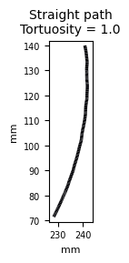

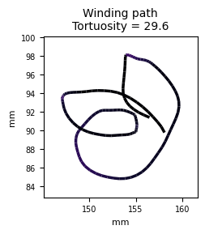

|  | Path length | Displacement | Tortuosity |
| --- | --- | --- | --- |
| Straightest 5s segment | 70.9 mm | 69.7 mm | **1.02** |
| Most winding 5s segment | 67.5 mm | 2.3 mm | **29.62** |

The **window size** controls the timescale over which tortuosity is evaluated. Short windows (0.5–1s) capture individual turns. Longer windows (3–7s) capture extended looping behaviour. Use the slider on each plot to explore different timescales.

The three trajectory subplots below show the **same fly** with tortuosity computed at three different window sizes (1s, 2s, 7s). Dark colours (low tortuosity) indicate straight segments; bright colours (high tortuosity) indicate winding or looping segments. The grey circle shows the physical arena boundary. Use the dropdown to switch between example flies from different distance zones.

## Example Trajectory

[interactive chart not shown]

## A. Tortuosity Distributions

Tortuosity distributions during the **stimulus** period, split by arena zone (distance from centre). The grey line shows the baseline (pre-stimulus) distribution across all zones for comparison. Dashed vertical lines indicate the mean for each distribution. Use the slider to change the analysis window size.

[interactive chart not shown]

| Distribution | Mean | Median | Std | N |
| --- | --- | --- | --- | --- |
| Inner (0–30 mm) | 5.25 | 3.76 | 4.98 | 103,857 |
| Inner-mid (30–60 mm) | 4.09 | 2.82 | 4.04 | 216,189 |
| Outer-mid (60–90 mm) | 2.78 | 1.94 | 2.73 | 176,717 |
| Outer (90–119 mm) | 2.30 | 1.57 | 2.36 | 76,857 |
| Baseline (all zones) | 1.36 | 1.16 | 0.86 | 162,267 |

### Statistical Analysis (3s window)

**Sample sizes (flies):** Inner: N=335 | Inner-mid: N=547 | Outer-mid: N=537 | Outer: N=335 | Baseline: N=647

**Kruskal-Wallis H-test (5 groups):** H = 1409.8, p = 5.26e-304 (significant)

Pairwise Mann-Whitney U tests with Bonferroni correction (10 comparisons, α = 0.05). Cliff’s δ effect size: |δ| < 0.147 negligible, < 0.33 small, < 0.474 medium, ≥ 0.474 large.

| Group A | Group B | N<sub>A</sub> | N<sub>B</sub> | MW-U p | Cliff’s δ | Effect |  |
| --- | --- | --- | --- | --- | --- | --- | --- |
| Inner | Inner-mid | 335 | 547 | 8.38e-23 | +0.403 | medium | * |
| Inner | Outer-mid | 335 | 537 | 2.74e-67 | +0.702 | large | * |
| Inner | Outer | 335 | 335 | 2.36e-55 | +0.706 | large | * |
| Inner | Baseline | 335 | 647 | 2.96e-137 | +0.973 | large | * |
| Inner-mid | Outer-mid | 547 | 537 | 8.18e-39 | +0.463 | medium | * |
| Inner-mid | Outer | 547 | 335 | 2.11e-33 | +0.490 | large | * |
| Inner-mid | Baseline | 547 | 647 | 6.45e-174 | +0.946 | large | * |
| Outer-mid | Outer | 537 | 335 | 0.1274 | +0.100 | negligible |  |
| Outer-mid | Baseline | 537 | 647 | 2.95e-138 | +0.847 | large | * |
| Outer | Baseline | 335 | 647 | 1.45e-81 | +0.748 | large | * |

Tests compare **per-fly median** tortuosity (one value per fly per group) to avoid pseudoreplication from frame-level data.

[interactive chart not shown]

## B. Mean Tortuosity by Radial Zone

[interactive chart not shown]

## C. Tortuosity Time Course

[interactive chart not shown]

**Assumptions & Methodological Notes**

[output not shown]